# Introdução ao Pandas

Dentre as diversas bibliotecas disponíveis no repositório PyPI, pandas é um pacote Python que fornece estruturas de dados projetadas para facilitar o trabalho com dados estruturados (tabelas) e de séries temporais.

Estruturas de dados:

- Series
- DataFrame

Series é um como um vetor de dados unidimencional capaz de armazenar diferentes tipos de dados.

DataFrame é conjunto de Series.

Possuem como característica a indexação das linhas

- Cada linha possui um rótulo (nome) que o identifica
  - Pode ser string, inteiro, decimal, ou data

## Também neste Notebook:

`requests` - biblioteca HTTP para ler páginas web

Beautiful Soup `bs4` - extrai informações de páginas web

```python
import pandas as pd
```

## Series

```python
pd.Series(data=5)
```

```
0    5
dtype: int64
```

```python
lista_nomes = 'Howard Ian Peter Jonah Kellie'.split()
lista_nomes
```

```
['Howard', 'Ian', 'Peter', 'Jonah', 'Kellie']
```

```python
pd.Series(lista_nomes)
```

```
0    Howard
1       Ian
2     Peter
3     Jonah
4    Kellie
dtype: object
```

```python
dados = {
'nome1': 'Howard',
'nome2': 'Ian',
'nome3': 'Peter',
'nome4': 'Jonah',
'nome5': 'Kellie',
}
```

```python
pd.Series(dados)
```

```
nome1    Howard
nome2       Ian
nome3     Peter
nome4     Jonah
nome5    Kellie
dtype: object
```

```python
cpfs = """
111.111.111-11 222.222.222-22 333.333.333-33
444.444.444-44 555.555.555-55
""".split()
cpfs
```

```
['111.111.111-11',
 '222.222.222-22',
 '333.333.333-33',
 '444.444.444-44',
 '555.555.555-55']
```

```python
series_dados = pd.Series(lista_nomes, index=cpfs)
series_dados
```

```
111.111.111-11    Howard
222.222.222-22       Ian
333.333.333-33     Peter
444.444.444-44     Jonah
555.555.555-55    Kellie
dtype: object
```

```python
series_dados.loc['111.111.111-11']
```

```
'Howard'
```

## Extraindo informações

```python
series_dados = pd.Series([10.2, -1, None, 15, 23.4])
```

```python
print('Quantidade de linhas = ', series_dados.shape)
```

```
Quantidade de linhas =  (5,)
```

```python
print('Tipo de dados', series_dados.dtypes)
```

```
Tipo de dados float64
```

```python
print('Os valores são únicos?', series_dados.is_unique)
```

```
Os valores são únicos? True
```

```python
print('Existem valores nulos?', series_dados.hasnans)
```

```
Existem valores nulos? True
```

```python
print('Quantos valores existem?', series_dados.count())
```

```
Quantos valores existem? 4
```

```python
print('Qual o menor valor?', series_dados.min())
```

```
Qual o menor valor? -1.0
```

```python
print('Qual o maior valor?', series_dados.max())
```

```
Qual o maior valor? 23.4
```

```python
print('Qual a média aritmética?', series_dados.mean())
```

```
Qual a média aritmética? 11.899999999999999
```

```python
print('Qual o desvio padrão?', series_dados.std())
```

```
Qual o desvio padrão? 10.184301645179211
```

```python
print('Qual a mediana?', series_dados.median())
```

```
Qual a mediana? 12.6
```

## DataFrame

```python
lista_nomes = 'Howard Ian Peter Jonah Kellie'.split()
lista_nomes
```

```
['Howard', 'Ian', 'Peter', 'Jonah', 'Kellie']
```

```python
lista_cpfs = """
111.111.111-11 222.222.222-22 333.333.333-33
444.444.444-44 555.555.555-55
""".split()
lista_cpfs
```

```
['111.111.111-11',
 '222.222.222-22',
 '333.333.333-33',
 '444.444.444-44',
 '555.555.555-55']
```

```python
lista_emails = """
risus.varius@dictumPhasellusin.ca  Nunc@vulputate.ca
fames.ac.turpis@cursusa.org  non@felisullamcorper.org
eget.dictum.placerat@necluctus.co.uk
""".split()
lista_emails
```

```
['risus.varius@dictumPhasellusin.ca',
 'Nunc@vulputate.ca',
 'fames.ac.turpis@cursusa.org',
 'non@felisullamcorper.org',
 'eget.dictum.placerat@necluctus.co.uk']
```

```python
lista_idades = [32, 22, 25, 29, 38]
lista_idades
```

```
[32, 22, 25, 29, 38]
```

```python
pd.DataFrame(lista_nomes, columns=['nome'])
```

|  | nome |
| --- | --- |
| 0 | Howard |
| 1 | Ian |
| 2 | Peter |
| 3 | Jonah |
| 4 | Kellie |

```python
pd.DataFrame(lista_nomes, columns=['nome'], index=lista_cpfs)
```

|  | nome |
| --- | --- |
| 111.111.111-11 | Howard |
| 222.222.222-22 | Ian |
| 333.333.333-33 | Peter |
| 444.444.444-44 | Jonah |
| 555.555.555-55 | Kellie |

`zip` retorna um iterador de tuplas, e `list` cria uma lista a partir das tuplas:

```python
a = ("John", "Charles", "Mike")
b = ("Jenny", "Christy", "Monica")
list(zip(a, b))
```

```
[('John', 'Jenny'), ('Charles', 'Christy'), ('Mike', 'Monica')]
```

Cria uma lista a partir das tuplas:

```python
dados = list(zip(lista_nomes, lista_cpfs, lista_idades, lista_emails))
dados
```

```
[('Howard', '111.111.111-11', 32, 'risus.varius@dictumPhasellusin.ca'),
 ('Ian', '222.222.222-22', 22, 'Nunc@vulputate.ca'),
 ('Peter', '333.333.333-33', 25, 'fames.ac.turpis@cursusa.org'),
 ('Jonah', '444.444.444-44', 29, 'non@felisullamcorper.org'),
 ('Kellie', '555.555.555-55', 38, 'eget.dictum.placerat@necluctus.co.uk')]
```

Cria um dataframe a partir da lista:

```python
pd.DataFrame(dados, columns=['nome', 'cpfs', 'idade', 'email'])
```

|  | nome | cpfs | idade | email |
| --- | --- | --- | --- | --- |
| 0 | Howard | 111.111.111-11 | 32 | risus.varius@dictumPhasellusin.ca |
| 1 | Ian | 222.222.222-22 | 22 | Nunc@vulputate.ca |
| 2 | Peter | 333.333.333-33 | 25 | fames.ac.turpis@cursusa.org |
| 3 | Jonah | 444.444.444-44 | 29 | non@felisullamcorper.org |
| 4 | Kellie | 555.555.555-55 | 38 | eget.dictum.placerat@necluctus.co.uk |

## DataFrame a partir de dicionário

As chaves são usadas como nomes das colunas:

```python
dados = {
    "nomes": "Howard Ian Peter Jonah Kellie".split(),
    "cpfs": """111.111.111-11 222.222.222-22 333.333.333-33
        444.444.444-44 555.555.555-55""".split(),
    "emails": """risus.varius@dictumPhasellusin.ca Nunc@vulputate.ca
    fames.ac.turpis@cursusa.org non@felisullamcorper.org
    eget.dictum.placerat@necluctus.co.uk""".split(),
    "idades": [32, 22, 25, 29, 38],
}
```

```python
df_dados = pd.DataFrame(dados)
df_dados
```

|  | nomes | cpfs | emails | idades |
| --- | --- | --- | --- | --- |
| 0 | Howard | 111.111.111-11 | risus.varius@dictumPhasellusin.ca | 32 |
| 1 | Ian | 222.222.222-22 | Nunc@vulputate.ca | 22 |
| 2 | Peter | 333.333.333-33 | fames.ac.turpis@cursusa.org | 25 |
| 3 | Jonah | 444.444.444-44 | non@felisullamcorper.org | 29 |
| 4 | Kellie | 555.555.555-55 | eget.dictum.placerat@necluctus.co.uk | 38 |

## Extraindo informações de um DataFrame

```python
print(df_dados.info())
```

```
<class 'pandas.core.frame.DataFrame'>
RangeIndex: 5 entries, 0 to 4
Data columns (total 4 columns):
 #   Column  Non-Null Count  Dtype
---  ------  --------------  -----
 0   nomes   5 non-null      object
 1   cpfs    5 non-null      object
 2   emails  5 non-null      object
 3   idades  5 non-null      int64
dtypes: int64(1), object(3)
memory usage: 288.0+ bytes
None
```

```python
print('Quantidade de linhas e colunas = ', df_dados.shape)
```

```
Quantidade de linhas e colunas =  (5, 4)
```

```python
print('Tipo de dados:\n', df_dados.dtypes)
```

```
Tipo de dados:
 nomes     object
cpfs      object
emails    object
idades     int64
dtype: object
```

```python
print('Qual o menor valor de cada coluna?\n', df_dados.min())
```

```
Qual o menor valor de cada coluna?
 nomes                Howard
cpfs         111.111.111-11
emails    Nunc@vulputate.ca
idades                   22
dtype: object
```

```python
print('Qual o maior valor?\n', df_dados.max())
```

```
Qual o maior valor?
 nomes                                 Peter
cpfs                         555.555.555-55
emails    risus.varius@dictumPhasellusin.ca
idades                                   38
dtype: object
```

```python
print('Resumo:\n', df_dados.describe())
```

```
Resumo:
           idades
count   5.000000
mean   29.200000
std     6.220932
min    22.000000
25%    25.000000
50%    29.000000
75%    32.000000
max    38.000000
```

```python
dados = { "idades": [32, 22, 25, 29, 38] }
dados
```

```
{'idades': [32, 22, 25, 29, 38]}
```

```python
df_dados = pd.DataFrame(dados)
df_dados
```

|  | idades |
| --- | --- |
| 0 | 32 |
| 1 | 22 |
| 2 | 25 |
| 3 | 29 |
| 4 | 38 |

```python
print('Qual a média aritmética?\n', df_dados.mean())
```

```
Qual a média aritmética?
 idades    29.2
dtype: float64
```

```python
print('Qual o desvio padrão?\n', df_dados.std())
```

```
Qual o desvio padrão?
 idades    6.220932
dtype: float64
```

```python
print('Qual a mediana?\n', df_dados.median())
```

```
Qual a mediana?
 idades    29.0
dtype: float64
```

## Seleção de colunas em um DataFrame

```python
dados = {
    "nomes": "Howard Ian Peter Jonah Kellie".split(),
    "cpfs": """111.111.111-11 222.222.222-22 333.333.333-33
        444.444.444-44 555.555.555-55""".split(),
    "emails": """risus.varius@dictumPhasellusin.ca Nunc@vulputate.ca
        fames.ac.turpis@cursusa.org non@felisullamcorper.org
        eget.dictum.placerat@necluctus.co.uk""".split(),
    "idades": [32, 22, 25, 29, 38],
}
```

```python
df_dados = pd.DataFrame(dados)
```

Seleciona a coluna "idades":

```python
df_dados["idades"]
```

```
0    32
1    22
2    25
3    29
4    38
Name: idades, dtype: int64
```

Média da coluna:

```python
df_dados["idades"].mean()
```

```
29.2
```

```python
colunas = ['nomes', 'cpfs']
colunas
```

```
['nomes', 'cpfs']
```

```python
df_duas_colunas = df_dados[colunas]
df_duas_colunas
```

|  | nomes | cpfs |
| --- | --- | --- |
| 0 | Howard | 111.111.111-11 |
| 1 | Ian | 222.222.222-22 |
| 2 | Peter | 333.333.333-33 |
| 3 | Jonah | 444.444.444-44 |
| 4 | Kellie | 555.555.555-55 |

```python
type(df_duas_colunas)
```

```
pandas.core.frame.DataFrame
```

## Requests e Beautiful Soup

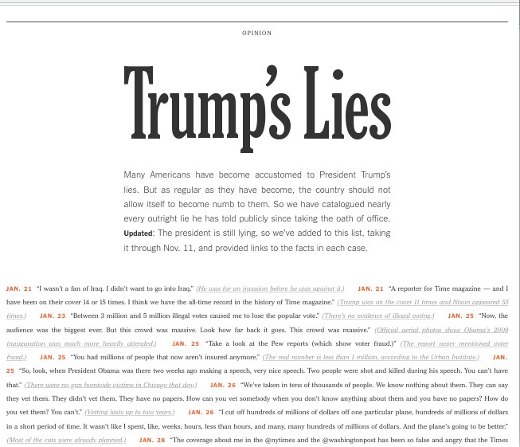

Se estiver usando o conda: `conda install requests`

```python
import requests
```

```python
texto_string = requests.get('https://www.nytimes.com/interactive/2017/06/23/opinion/trumps-lies.html').text
```

```python
texto_string[:100]
```

```
'<!DOCTYPE html>\n<!--[if (gt IE 9)|!(IE)]> <!--><html lang="en" class="no-js page-interactive section'
```

O Beautiful Soup já está instalado no Colab. Se estiver em outra máquina usando o conda: `conda install bs4`

```python
from bs4 import BeautifulSoup
```

```python
bsp_texto = BeautifulSoup(texto_string, 'html.parser')
```

```python
lista_noticias = bsp_texto.find_all('span', attrs={'class':'short-desc'})
lista_noticias[3]
```

[output not shown]

```python
lista_noticias[3].contents
```

```
[<strong>Jan. 25 </strong>,
 '“Now, the audience was the biggest ever. But this crowd was massive. Look how far back it goes. This crowd was massive.” ',
 <span class="short-truth"><a href="https://www.nytimes.com/2017/01/21/us/politics/trump-white-house-briefing-inauguration-crowd-size.html" target="_blank">(Official aerial photos show Obama's 2009 inauguration was much more heavily attended.)</a></span>]
```

### Transformando em um dataFrame

Primeiro cria uma lista, e faz umas "limpezas" no hmtl:

```python
dados = []
for noticia in lista_noticias:
    data = noticia.contents[0].text.strip() + ', 2017'
    comentario = noticia.contents[1].strip().replace("“", '').replace("”", '')
    explicacao = noticia.contents[2].text.strip().replace("(", '').replace(")", '')
    url = noticia.find('a')['href']
    dados.append((data, comentario, explicacao, url))
```

```python
dados[1]
```

```
('Jan. 21, 2017',
 'A reporter for Time magazine — and I have been on their cover 14 or 15 times. I think we have the all-time record in the history of Time magazine.',
 'Trump was on the cover 11 times and Nixon appeared 55 times.',
 'http://nation.time.com/2013/11/06/10-things-you-didnt-know-about-time/')
```

Une os dados com os títulos das colunas para criar o dataFrame:

```python
df_noticias = pd.DataFrame(dados, columns=['data', 'comentário', 'explicação', 'url'])
df_noticias[:4]
```

|  | data | comentário | explicação | url |
| --- | --- | --- | --- | --- |
| 0 | Jan. 21, 2017 | I wasn't a fan of Iraq. I didn't want to go in... | He was for an invasion before he was against it. | https://www.buzzfeed.com/andrewkaczynski/in-20... |
| 1 | Jan. 21, 2017 | A reporter for Time magazine — and I have been... | Trump was on the cover 11 times and Nixon appe... | http://nation.time.com/2013/11/06/10-things-yo... |
| 2 | Jan. 23, 2017 | Between 3 million and 5 million illegal votes ... | There's no evidence of illegal voting. | https://www.nytimes.com/2017/01/23/us/politics... |
| 3 | Jan. 25, 2017 | Now, the audience was the biggest ever. But th... | Official aerial photos show Obama's 2009 inaug... | https://www.nytimes.com/2017/01/21/us/politics... |

## Outro exemplo

[figure not shown]

```python
url = 'https://www.fdic.gov/resources/resolutions/bank-failures/failed-bank-list/'
dfs = pd.read_html(url)
```

```python
dfs
```

```
[                         Bank NameBank       CityCity StateSt  CertCert  \
 0             Heartland Tri-State Bank        Elkhart      KS     25851
 1                  First Republic Bank  San Francisco      CA     59017
 2                       Signature Bank       New York      NY     57053
 3                  Silicon Valley Bank    Santa Clara      CA     24735
 4                    Almena State Bank         Almena      KS     15426
 ..                                 ...            ...     ...       ...
 562                 Superior Bank, FSB       Hinsdale      IL     32646
 563                Malta National Bank          Malta      OH      6629
 564    First Alliance Bank & Trust Co.     Manchester      NH     34264
 565  National State Bank of Metropolis     Metropolis      IL      3815
 566                   Bank of Honolulu       Honolulu      HI     21029

                  Acquiring InstitutionAI Closing DateClosing  FundFund
 0                 Dream First Bank, N.A.       July 28, 2023     10544
 1              JPMorgan Chase Bank, N.A.         May 1, 2023     10543
 2                    Flagstar Bank, N.A.      March 12, 2023     10540
 3    First–Citizens Bank & Trust Company      March 10, 2023     10539
 4                            Equity Bank    October 23, 2020     10538
 ..                                   ...                 ...       ...
 562                Superior Federal, FSB       July 27, 2001      6004
 563                    North Valley Bank         May 3, 2001      4648
 564  Southern New Hampshire Bank & Trust    February 2, 2001      4647
 565              Banterra Bank of Marion   December 14, 2000      4646
 566                   Bank of the Orient    October 13, 2000      4645

 [567 rows x 7 columns]]
```

```python
df_bancos = dfs[0][0:4]
df_bancos
```

|  | Bank NameBank | CityCity | StateSt | CertCert | Acquiring InstitutionAI | Closing DateClosing | FundFund |
| --- | --- | --- | --- | --- | --- | --- | --- |
| 0 | Heartland Tri-State Bank | Elkhart | KS | 25851 | Dream First Bank, N.A. | July 28, 2023 | 10544 |
| 1 | First Republic Bank | San Francisco | CA | 59017 | JPMorgan Chase Bank, N.A. | May 1, 2023 | 10543 |
| 2 | Signature Bank | New York | NY | 57053 | Flagstar Bank, N.A. | March 12, 2023 | 10540 |
| 3 | Silicon Valley Bank | Santa Clara | CA | 24735 | First–Citizens Bank & Trust Company | March 10, 2023 | 10539 |

```python
df_bancos.shape
```

```
(4, 7)
```

```python
df_bancos.dtypes
```

```
Bank NameBank              object
CityCity                   object
StateSt                    object
CertCert                    int64
Acquiring InstitutionAI    object
Closing DateClosing        object
FundFund                    int64
dtype: object
```